# Working with Markdown

Emily Dombrowski

2024-01-23

This is a practice document with markdown formatting and practice LaTex commands.

For markdown, use asterisks to *indicate italic text*.

Double line return for a new chunk of text like this.

Emily Dombrowski  
Department of Biology  
University of Vermont

# Hash marks for headers

## More hashes for progressively

### smaller

#### headers!

**Boldface font with double asterisk**

> Offset quote which embeds and looks really nice when you have extended material that you would like to see.
- first list item
  - Item 2

<sup>superscripts</sup> but also <sub>subscripts</sub> like this

set up a link with text

also footnotes[^1]

| First header | Second header |
| --- | --- |
| Content cell | Content cell |
| Content cell | Content cell |

```
Fencing sets boundaries and everything inside the fencing *is shown as literal text* without rendering
```

$$a + b =c$$

We can also use Latex in line with a single dollar sign $a +b=c$ like this.

## Subscripts in LaTex

$$H_0 = Z_{a +b}$$

$$S=cA^z_1 + z_{a+b}$$

## Fractions and greek letters

$${\alpha = \frac{\beta}{\delta +
\gamma_x}}$$

$$z + \sum_{i=1}^X{k}$$

## Escaping the backslash character

$$\backslash \alpha \le b
\backslash$$

## Rendering in plain text

$$P(Occurrence of Species A) = Z$$
…looks wrong! Renders plain text as mathmatical variables.

$$P(\mbox{Occurrence of Species A}) =
Z$$
Used mbox command which alleviates this issue

Easy to embed latex in line $\pi + 3$ like so. We can also use markdown fencing in line with a single backtick `pi + 3` like this. We can even execute r code inside of markdown text 6.1415927 (reads out as computed answer rather than unformatted code.)

```
##  [1] 0.4820014 0.4842683 0.6903992 0.2295593 0.4706668 0.6316228 0.6636863
##  [8] 0.1899452 0.3921626 0.5687920
```

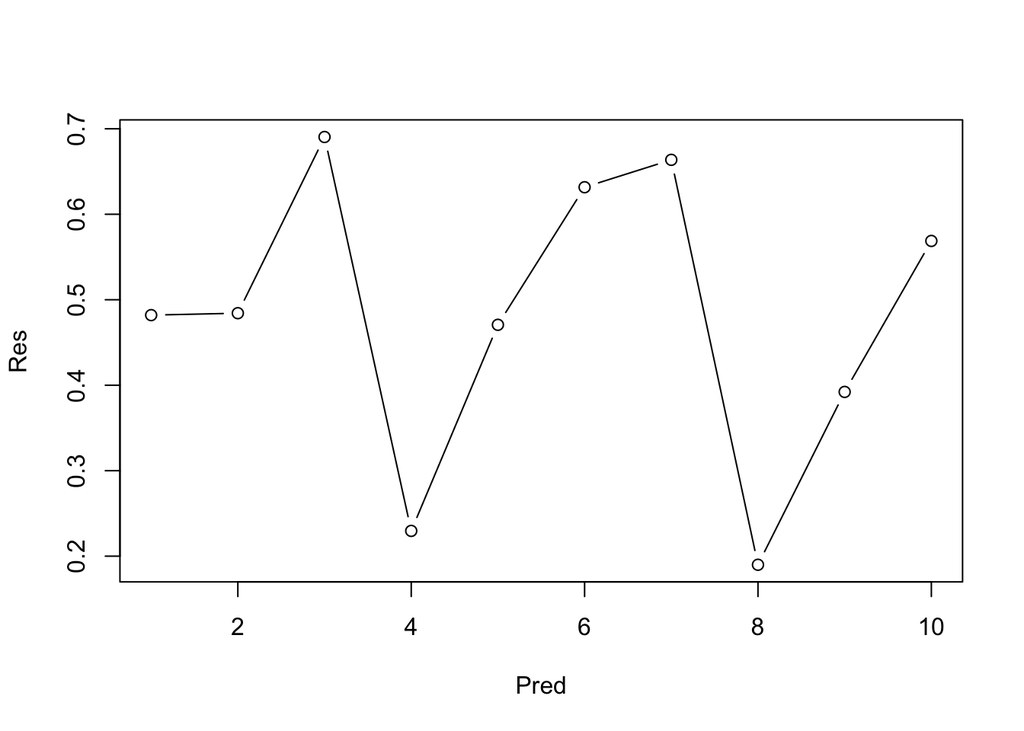

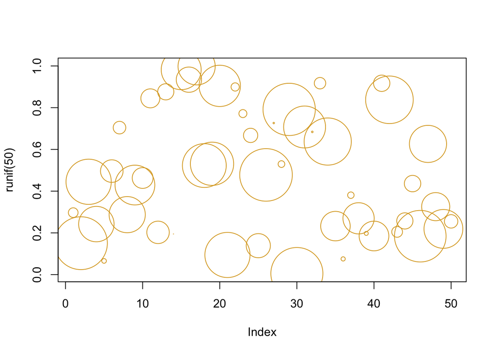

```r
plot(runif(50),cex=10*runif(50),col="goldenrod")
```

[^1]: at bottom of page